# Community Audit<sup>©</sup> Report: London Road, Barking IG11 8FW

### The Community Audit<sup>©</sup>, is a collection of Big Data variables intended to give a snapshot of the strengths and weaknesses of the neighbourhood around your proposed development site. It covers aspects from schools to leisure to convenience retail and is mapped to postcode level nationwide. The data is aimed at providing an initial dipstick to trigger conversations about planning, what customer segments your scheme could target, as well as what can be implemented in your commercial/public spaces.

#### All scores have been scaled to between 0 and 100, with 100 being the best performing postcode and 0 being the worst for **500** postcodes across London. The postcode a development is in, is compared to other regional postcodes, e.g., only postcodes within London are compared to each other etc. Walkability refers to our in-house proprietary algorithm, which calculates the time taken to walk to each amenity/service and assigns a score. This score is based on the walkability of *all* amenities/services within a given category, e.g., the walkability from the development site to *all* greenspace within the neighbourhood. Provision scores are the number of services/amenities which are within a walkable distance of a development. **Legend:** 0 -33 Low score 33-66 Medium Score 66-100 High Score

[figure not shown]

# Community Audit Score

# Ranked **26th** best

#### Out of a selection of 500 london postcodes

#### Family features Education Number Early Years 40 Primary Schools 21 Secondary Schools 21 Average OFSTED rating Early Years 33 Primary Schools 40 Secondary Schools 67 Walkability Early Years 75 Primary Schools 71 Secondary Schools 53 Playgrounds Number 44 Walkability 48 Leisure & Entertainment General L&E Number 8 Walkability 75 Nightlife Number 8 Walkability 88 Cafes, restaurants etc. Number 4 Walkability 81 Convenience amenities/services Number 27 Walkability 74 Third Places** Number 12 Walkability 42 Transport Number 11 Walkability 82 Walkable tube/train station 100* Greenspace Is there a sizable walkable space?*** 100 Walkability 6 Crime Score 20

*If there is a walkable tube/train station, a score of 100 is given, if not, a 0 is given

**Third places include amenities/services such as libraries, community centres, art centres etc.

***Those postcodes within a walkable distance of a greenspace above 2 ha in size are given a score of 100 and those without, a score of 0

## Top 10 Community Audit Score<sup>©</sup> locations ranked

| Rank | Postcode | Area |
| --- | --- | --- |
| 2 | WC1A 1HD | Holborn and St Pancras |
| 2 | WC1A 2SD | Holborn and St Pancras |
| 4 | WC1V 7AA | Holborn and St Pancras |
| 4 | WC1V 7AP | Holborn and St Pancras |
| 4 | WC1B 3HN | Holborn and St Pancras |
| 6 | E1 2FF | Poplar and Limehouse |
| 7 | CR9 1QP | Croydon Central |
| 10 | EC1R 0HR | Islington South and Finsbury |
| 10 | E7 9AA | West Ham |
| 10 | SW9 8HE | Dulwich and West Norwood |

[figure not shown]

## Walkability Score

## Ranked **4th** most walkable

[figure not shown]

## Provision Score

## Ranked **174th** for no. amenities/services

### Top 10 locations ranked

| Rank | Postcode | Area |
| --- | --- | --- |
| 1 | EN5 4BJ | Chipping Barnet |
| 2 | CR9 1QP | Croydon Central |
| 4 | IG11 8FW | Barking |
| 4 | UB7 7TT | Uxbridge and South Ruislip |
| 4 | IG11 7LZ | Barking |
| 4 | N3 1SX | Finchley and Golders Green |
| 7 | SE28 8DZ | Erith and Thamesmead |
| 10 | EN4 0JJ | Enfield, Southgate |
| 10 | DA16 1TN | Bexleyheath and Crayford |
| 10 | SW9 8HE | Dulwich and West Norwood |

| Rank | Postcode | Area |
| --- | --- | --- |
| 2 | WC1B 3HN | Holborn and St Pancras |
| 2 | WC1E 6HP | Holborn and St Pancras |
| 3 | WC1A 1HD | Holborn and St Pancras |
| 4 | WC1E 7AS | Holborn and St Pancras |
| 5 | W1T 4PR | Holborn and St Pancras |
| 6 | WC1V 7AA | Holborn and St Pancras |
| 8 | WC1A 2SD | Holborn and St Pancras |
| 8 | WC1V 7AP | Holborn and St Pancras |
| 10 | W1W 7BB | Cities of London and Westminster |
| 10 | WC2A 3PF | Cities of London and Westminster |

## Which segments could your development target?

#### Below you will see the ranking for four BTR customer segments as well as a breakdown of some of the most important features for these groups.

## **Young Urbanites**

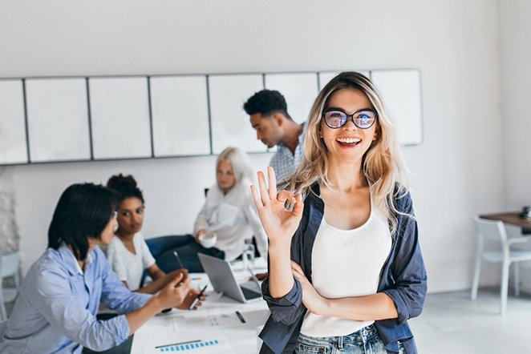

### Ranked

# **32nd**

### for best neighbourhood to cater for Young Urbanites

#### L&E: 42/100

#### Night.life: 48/100

#### F&B: 43/100

## **Young Families**

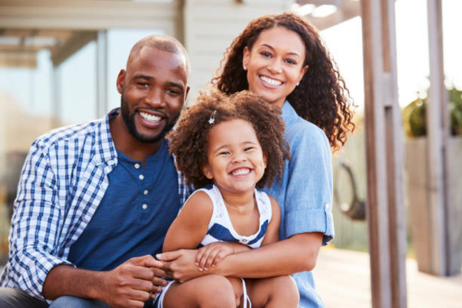

### Ranked

# **111th**

### for best neighbourhood to cater for Young Families

#### Education score(early years/primary): 47/100

#### Playground score: 46/100

#### % Households with children*: 100/100

## **Mature Families**

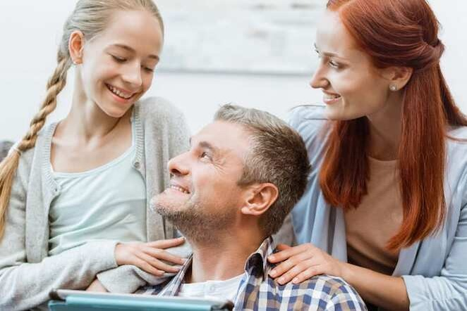

### Ranked

# **135th**

### for best neighbourhood to cater for Mature Families

#### Education score (secondary): 47/100

#### L&E score: 42/100

#### Third places: 27/100

## **Empty Nesters**

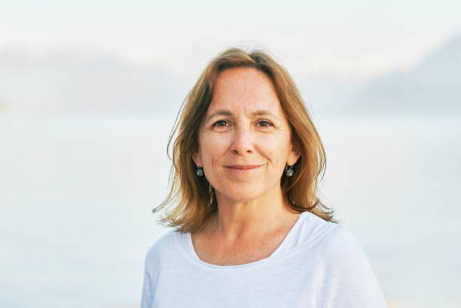

### Ranked

# **124th**

### for best neighbourhood to cater for Empty Nesters

#### Health: 43/100

#### Convenience retail: 50/100

#### F&B: 43/100

*Taken from Census 2021 data. The % households with children data was scaled across all postcodes between 0 and 100. The higher the score, the more households with children there are in an area

### How does your proposed development location compare to the locations the "HomeViews Top 10 London developments" are in?

#### All numbers refer to the ranking/500; with one being the highest ranked and 500 being the lowest.

| Development name | Postcode | Young Urbanites rank | Young Families rank | Mature Families rank | Empty Nesters rank |
| --- | --- | --- | --- | --- | --- |
| **Abbeville Apartments** | IG11 8FW | 32 | 111 | 135 | 124 |
| 8 Water Street | E14 5GX | 384 | 479 | 471 | 476 |
| The Quarters Croydon | CR0 9BN | 48 | 126 | 95 | 105 |
| be:here Hayes | UB3 1AJ | 481 | 477 | 462 | 468 |
| The Quarters Kilburn | NW6 5UA | 149 | 140 | 256 | 62 |
| Sailmakers, Isle of Dogs | E14 9ZP | 213 | 176 | 201 | 204 |
| 10 George Street | E14 9QG | 468 | 492 | 485 | 490 |
| Vantage Point | N19 5RQ | 137 | 208 | 216 | 122 |
| Bradstowe House | HA1 1EH | 187 | 194 | 166 | 255 |
| Elephant Central | SE1 6TJ | 148 | 38 | 57 | 101 |
| Fizzy Lewisham | SE13 5FQ | 56 | 133 | 84 | 64 |

## What could you integrate into the commercial/public realm?

#### Focusing in on features which could form a part of your ground floor commercial/public spaces and how these are currently served in the surrounding community.

#### Fitness centres/gyms 3 58 Cafes/ coffee shops 6 83 Larger supermarkets* 3 83 Convenience supermarkets** 1 75 Third places Library 1 75 Arts centre 0 NA Community centre 3 42 Events centre 0 NA

*Only considers "the big 6" larger supermarkets: Waitrose,  
M&S, Tescos, Sainsburys, Aldi and Lidl

**Only considers "the big 4" convenience supermarkets: Little Waitrose,  
M&S Simply Food, Tesco Express and Sainsburys Local

[interactive chart not shown]

## Landuse map of the surrounding community

[interactive chart not shown]

## Isolating relevant Census 2021 data for the area